# STA 506 Final Examination

Matthew Gray

Due: May 5, 2026

## **Final Exam Guidelines**

- **Coverage**: The major concepts and inference procedures—such as sampling distributions, confidence intervals, and hypothesis testing—are covered and implemented using both classical parametric likelihood-based methods and modern non-parametric approaches, including the bootstrap and kernel density estimation.
- **Part A** requires derivation of selected likelihood-based functions for performing various types of inference, with sufficient detail to enable translation of these derivations into code for numerical analysis.
- Your code for the problems in **Part B** must align with your derivations in **Part A** and be well commented where necessary.
- In **Part B**, all numerical results must be interpreted from a practical perspective.

## **Policies of Using AI Tools**

- **Policy on AI Tool Use**: Students must adhere to the AI tool policy specified in the course syllabus. The direct copying of AI-generated content is strictly prohibited. All submitted work must reflect your own understanding; where external tools are consulted, content must be thoroughly rephrased and synthesized in your own words.
- **Code Inclusion Requirement**: Any code included in your essay must be properly commented to explain the purpose and/or expected output of key code lines. Submitting AI-generated code without meaningful, student-added comments will not be accepted.

## **Working Model for the Final Exam**

**Caution**: *Please follow the suggested expressions and guided steps to complete the exam. Other approaches such as transformation for trivialize the problems that will not meet the exam objectives.*

The **Kumaraswamy distribution** is a two-parameter continuous probability distribution defined on the interval (0, 1). It is often used as an alternative to the Beta distribution due to its simple closed-form expressions for the cumulative distribution function (CDF) and quantile function. It is commonly used in

- **Hydrology**: Modeling rainfall, streamflow, or other bounded natural phenomena
- **Economics**: Income shares, proportions, or bounded indices
- **Monte Carlo simulation**: Efficient random variate generation (via inverse transform)
- **Machine learning**: Output layer for bounded targets, prior distributions in Bayesian models
- **Reliability engineering**: Modeling failure rates of systems with bounded lifetimes

Let $X$ be the Kumaraswamy random variable with Cumulative Distribution Function (CDF)

$$F(x; a, b) = 1 - (1 - x^a)^b$$

where $a > 0$ and $b > 0$ unknown parameters and $0 < x < 1$.

The following are two special case of the Kumaraswamy distribution:

1. **Uniform Distribution**: When $a = 1$ and $b = 1$, the Kumaraswamy distribution becomes a uniform distribution over $[0, 1]$ with CDF $F(x) = x$.
2. **Power Distribution**: when $b = 1$ and $a > 0$, the Kumaraswamy distribution becomes a power distribution over $[0, 1]$ with CDF $F(x) = x^a$.

This final exam focuses on inferences of Kumaraswamy distribution and related data analysis.

## Part A: Methodological Derivations

### **Problem A1**:

Show that the density function of the Kumaraswamy distribution is

$$f(x; a, b) = ab \, x^{a-1} (1 - x^a)^{b-1}.$$
Recall:

$$F(x;a,b) = 1 - \left(1 - x^{a}\right)^{b}$$

$$\frac{d}{dx} F(x;a,b) = f(x;a,b)$$

Apply the chain rule:

$$f(x;a,b)
= -\, b\left(1 - x^{a}\right)^{\,b-1}
\cdot \frac{d}{dx}\left(1 - x^{a}\right)$$

Differentiate the inner term:

$$f(x;a,b)
= -\, b\left(1 - x^{a}\right)^{\,b-1}
\cdot (-a x^{a-1})$$

Simplify:

$$\boxed{
f(x;a,b)
= a b\, x^{a-1}\left(1 - x^{a}\right)^{\,b-1}
}$$

### **Problem A2**:

Let $\{x_1, x_2, \cdots, x_n \}$ be an i.i.d. random sample taken from a population that follows the aove 2-parameter Kumaraswamy distribution. Write out the loglikelihood function of $a$ and $b$, denoted by $\ell(a,b)$, based on the above random sample and **derive** the gradient vector $[\ell_a^\prime(a,b), \ell_b^\prime(a,b)]$, the first order partial derivative of the log-likelihood with respect to parameters $a$ and $b$.

Likelihood function:
$$L(\theta \mid x)
= \prod_{i=1}^n \left[ a b\, x_i^{a-1}\left(1 - x_i^{a}\right)^{\,b-1}
\right]$$

Log-likelihood function:
$$\ell(\theta \mid x)
= \sum_{i=1}^n
\log\!\left(
a b\, x_i^{a-1}\left(1 - x_i^{a}\right)^{\,b-1}
\right)$$

Simplification:
$$\sum_{i=1}^n
\left[
\log a
+ \log b
+ \log x_i^{a-1}
+ \log\left(1 - x_i^{a}\right)^{\,b-1}
\right]$$

$$\sum_{i=1}^n
\left[
\log a
+ \log b
+ (a-1)\log x_i
+ (b-1)\log\left(1 - x_i^{a}\right)
\right]$$

$$\boxed{
\ell(\theta \mid x)
= n \log a
+ n \log b
+ (a-1)\sum_{i=1}^n \log x_i
+ (b-1)\sum_{i=1}^n \log\left(1 - x_i^{a}\right)
}$$

Gradient:
$$\boxed{
\frac{\partial \ell}{\partial a}
= \frac{n}{a}
+ \sum_{i=1}^n \log x_i
+ (b-1)\sum_{i=1}^n \frac{-x_i^{a}\ln(x_i)}{1 - x_i^{a}}
}$$

$$\boxed{
\frac{\partial \ell}{\partial b}
= \frac{n}{b}
+ \sum_{i=1}^n \log\left(1 - x_i^{a}\right)
}$$

### **Problem A3**:

Based on the gradients functions obtained in the above problem A2, **derive** the observed Fisher Information matrix (i.e, the negative Hessian Matrix).

The Hessian matrix is the square matrix of second-order partial derivatives:
$$H(a,b)
=
\begin{pmatrix}
\displaystyle \frac{\partial^2 \ell}{\partial a^2}
&
\displaystyle \frac{\partial^2 \ell}{\partial a \partial b}
\\\\
\displaystyle \frac{\partial^2 \ell}{\partial b \partial a}
&
\displaystyle \frac{\partial^2 \ell}{\partial b^2}
\end{pmatrix}$$

Compute $\partial^2 \ell / \partial a^2$:
$$\frac{\partial^2 \ell}{\partial a^2}
=
\frac{\partial}{\partial a}
\left(
\frac{n}{a}
+ \sum_{i=1}^n \log x_i
+ (b-1)\sum_{i=1}^n \frac{-x_i^{a}\ln(x_i)}{1 - x_i^{a}}
\right)$$

$$-\frac{n}{a^2}
+ (b-1)\sum_{i=1}^n
\frac{\partial}{\partial a}
\left(
\frac{-x_i^{a}\ln(x_i)}{1 - x_i^{a}}
\right)$$

Quotient rule:

$$\frac{\partial}{\partial a}
\left(
\frac{u(a)}{v(a)}
\right)
=
\frac{u'(a)v(a) - u(a)v'(a)}{[v(a)]^2}$$

Substitute and simplify:
$$\frac{\partial}{\partial a}
\left(
\frac{-x_i^{a}\ln(x_i)}{1 - x_i^{a}}
\right)
=
\frac{
\left[-x_i^{a}(\ln x_i)^2\right](1 - x_i^{a})
-
\left[-x_i^{a}\ln(x_i)\right]\left[-x_i^{a}\ln(x_i)\right]
}{
(1 - x_i^{a})^2
}
=
-\frac{x_i^{a}(\ln x_i)^2}{(1 - x_i^{a})^2}$$

$$\boxed{
\frac{\partial^2 \ell}{\partial a^2}
= -\frac{n}{a^2}
- (b-1)\sum_{i=1}^n
\frac{x_i^{a}(\ln x_i)^2}{(1 - x_i^{a})^2}
}$$

Compute $\partial^2 \ell / \partial b \partial a$:
$$\frac{\partial^2 \ell}{\partial b \partial a}
=
\frac{\partial}{\partial b}
\left(
\frac{n}{a}
+ \sum_{i=1}^n \log x_i
+ (b-1)\sum_{i=1}^n \frac{-x_i^{a}\ln(x_i)}{1 - x_i^{a}}
\right)$$

$$\boxed{
\frac{\partial^2 \ell}{\partial b \partial a}
=
\sum_{i=1}^n \frac{-x_i^{a}\ln(x_i)}{1 - x_i^{a}}
}$$

$\partial^2 \ell / \partial a \partial b$ is equivalent by Clairaut’s Theorem:
$$\boxed{
\frac{\partial^2 \ell}{\partial a \partial b}
=
\sum_{i=1}^n \frac{-x_i^{a}\ln(x_i)}{1 - x_i^{a}}
}$$

Compute $\partial^2 \ell / \partial b^2$:
$$\frac{\partial^2 \ell}{\partial b^2}
=
\frac{\partial}{\partial b}
\left(
\frac{n}{b}
+ \sum_{i=1}^n \log\left(1 - x_i^{a}\right)
\right)$$

$$\boxed{
\frac{\partial^2 \ell}{\partial b^2}
= -\frac{n}{b^2}
}$$

Create the observed Hessian by plugging in $\hat{a}$ and $\hat{b}$ estimates:
$$H(\hat{a},\hat{b})
=
\begin{pmatrix}
\displaystyle \frac{\partial^2 \ell}{\partial \hat{a}^2}
&
\displaystyle \frac{\partial^2 \ell}{\partial \hat{a} \partial \hat{b}}
\\\\
\displaystyle \frac{\partial^2 \ell}{\partial \hat{b} \partial \hat{a}}
&
\displaystyle \frac{\partial^2 \ell}{\partial \hat{b}^2}
\end{pmatrix}$$

Create the observed Fisher Information by taking the negative of the observed Hessian:
$$I(\hat{a},\hat{b})
=
-\begin{pmatrix}
\displaystyle \frac{\partial^2 \ell}{\partial \hat{a}^2}
&
\displaystyle \frac{\partial^2 \ell}{\partial \hat{a} \partial \hat{b}}
\\\\
\displaystyle \frac{\partial^2 \ell}{\partial \hat{b} \partial \hat{a}}
&
\displaystyle \frac{\partial^2 \ell}{\partial \hat{b}^2}
\end{pmatrix}$$

Substitute:
$$I(\hat{a},\hat{b})
=
-\begin{pmatrix}
\displaystyle -\frac{n}{\hat{a}^2}
- (\hat{b}-1)\sum_{i=1}^n
\frac{x_i^{\hat{a}}(\ln x_i)^2}{(1 - x_i^{\hat{a}})^2}
&
\displaystyle \sum_{i=1}^n \frac{-x_i^{\hat{a}}\ln(x_i)}{1 -
x_i^{\hat{a}}}
\\\\
\displaystyle \sum_{i=1}^n \frac{-x_i^{\hat{a}}\ln(x_i)}{1 -
x_i^{\hat{a}}}
&
\displaystyle -\frac{n}{\hat{b}^2}
\end{pmatrix}$$

Distribute the negative:
$$\boxed{
I(\hat{a},\hat{b})
=
\begin{pmatrix}
\displaystyle \frac{n}{\hat{a}^2}
+ (\hat{b}-1)\sum_{i=1}^n
\frac{x_i^{\hat{a}}(\ln x_i)^2}{(1 - x_i^{\hat{a}})^2}
&
\displaystyle \sum_{i=1}^n \frac{x_i^{\hat{a}}\ln(x_i)}{1 -
x_i^{\hat{a}}}
\\\\
\displaystyle \sum_{i=1}^n \frac{x_i^{\hat{a}}\ln(x_i)}{1 -
x_i^{\hat{a}}}
&
\displaystyle \frac{n}{\hat{b}^2}
\end{pmatrix}
}$$

### **Problem A4**:

Consider power distribution $F(x) = x^a, (a >0 \quad \text{ and }\quad x \in (0,1))$, a special case of the Kumaraswamy distribution with $b = 1$, and a random sample from this distribution $\{ x_1, x_2, \cdots, x_n\}$. **Derive** the MLE and MME of $a$ respectively. [*Hint: To find the MME, you need to compute the moment of the power distribution; that is, $E[X^k] = \int_0^1 x^k F'(x) dx$. Note that both the MLE and the MME have closed-form expressions.*]

**MLE:**

PDF of the power distribution:
$$f(x) = F'(x) = a x^{a-1}, \quad 0<x<1$$

Likelihood function:
$$L(\theta \mid x)
= \prod_{i=1}^n \left[ a \, x_i^{a-1}\right]$$

Log-likelihood function:
$$\ell(\theta \mid x)
= \sum_{i=1}^n
\log\!\left(
a \, x_i^{a-1}\right)$$

Simplification:
$$\sum_{i=1}^n
\left[
\log a
+ \log x_i^{a-1}
\right]
=
\sum_{i=1}^n
\left[
\log a
+ (a-1)\log x_i
\right]
=
n \log a
+ (a-1)\sum_{i=1}^n \log x_i$$

Gradient:
$$\frac{\partial \ell}{\partial a}
= \frac{n}{a}
+ \sum_{i=1}^n \log x_i$$

Score equation:
$$0
= \frac{n}{a}
+ \sum_{i=1}^n \log x_i$$

Solve the score equation for $a$:
$$- \frac{n}{a} = \sum_{i=1}^n \log x_i
\quad\Rightarrow\quad
- n = a \sum_{i=1}^n \log x_i$$

$$\boxed{
\hat a_{\text{MLE}} = \frac{-n}{\sum_{i=1}^n \log x_i}
}$$

**MME:**

For single parameter estimation, only match the first moment:
$$E[X] = m_1$$

Definition of the first sample moment:
$$m_1 = \frac{1}{n}\sum_{i=1}^n x_i$$

Recall the PDF of the power distribution:
$$f(x) = a x^{a-1}, \quad 0<x<1$$

Derive the first population moment:
$$E[X^1] = \int_0^1 x^1 f(x)\,dx
= \int_0^1 x^1 \, a x^{a-1}\,dx
= a \int_0^1 x^{a+1-1}\,dx
= a \left[ \frac{x^{a+1}}{a+1} \right]_0^1
= \frac{a}{a+1}$$

Set the first population moment equal to the first sample moment and solve for $a$:
$$\frac{a}{a+1} = m_1
\quad\Rightarrow\quad
a = m_1(a+1)
\quad\Rightarrow\quad
a = m_1 a + m_1
\quad\Rightarrow\quad
a - m_1 a = m_1
\quad\Rightarrow\quad
a(1 - m_1) = m_1$$

$$\boxed{
\hat a_{\text{MME}} = \frac{m_1}{1 - m_1}
}$$

### **Problem A5**:

Using the same setting as in **Problem A4**, find the asymptotic (Wald) confidence interval for $a$. [*Hint: Compute the Fisher information for $a$, then take its reciprocal to obtain the variance*.]

Recall gradient:
$$\frac{\partial \ell}{\partial a}
= \frac{n}{a}
+ \sum_{i=1}^n \log x_i$$

Observed fisher information is just a scalar:
$$I(\hat{a})
=
-\frac{\partial^2 \ell}{\partial \hat{a}^2}
= \frac{n}{\hat{a}^2}$$

Find the asymptotic distribution:
$$\hat a \xrightarrow{d} N\!\left(a,\; \frac{1}{I(\hat a)}\right)
= N\!\left(a,\; \frac{\hat a^{2}}{n}\right)$$

Standardize:
$$\frac{\hat{a} - a}{\sqrt{\hat{a}^{2}/n}}
=
\frac{\hat{a} - a}{\hat{a}/\sqrt{n}}
\xrightarrow{d} N(0,1)$$

Construct CI:
$$P\!\left(
- z_{1-\alpha/2}
\;\le\;
\frac{\hat a - a}{\hat a/\sqrt{n}}
\;\le\;
z_{1-\alpha/2}
\right)
\;\Rightarrow\;
P\!\left(
- z_{1-\alpha/2}\,\frac{\hat a}{\sqrt{n}}
\;\le\;
\hat a - a
\;\le\;
z_{1-\alpha/2}\,\frac{\hat a}{\sqrt{n}}
\right)
\;\Rightarrow\;
P\!\left(
\hat a - z_{1-\alpha/2}\,\frac{\hat a}{\sqrt{n}}
\le
a
\le
\hat a + z_{1-\alpha/2}\,\frac{\hat a}{\sqrt{n}}
\right)
\approx 1 - \alpha$$

$$\boxed{
\hat a \;\pm\; z_{1-\alpha/2}\,
\frac{\hat a}{\sqrt{n}}
}$$

### **Problem A6**:

Using the same setting as in **Problem A4**, perform a likelihood ratio test for the hypothesis $H_0 :a=1$ (i.e., the power distribution reduces to a uniform distribution). [*Hint: Evaluate the log-likelihood function at the maximum likelihood estimate $\hat{a}$ and at $a=1$, then use these values to construct the LRT test statistic.*]

Recall log-likelihood function:
$$\ell(\theta \mid x)
= n \log a
+ (a-1)\sum_{i=1}^n \log x_i$$

Likelihood ratio test statistic:
$$\Lambda
= 2\big(\ell(a = \hat a_{\text{MLE}}) - \ell(a = 1)\big)
= 2\big(\ell(a = \hat a_{\text{MLE}}))$$

Recall MLE:
$$\hat a_{\text{MLE}} = \frac{-n}{\sum_{i=1}^n \log x_i}$$

Substitute:
$$\Lambda
= 2\left[
n \log\!\left(-\frac{n}{\sum_{i=1}^n \log x_i}\right)
- n
- \sum_{i=1}^n \log x_i
\right]$$

State the distribution:
$$\Lambda \xrightarrow{d} \chi^2_1$$

Conclusion:
$$\text{Reject } H_0 \quad \text{if} \quad \Lambda >
\chi^2_{1,\,1-\alpha}$$

## Part B: Numerical Analysis

**All code must be well commented and adhere to best coding practices**

**Working Dataset**: A small reservoir supplies water to a town. During the dry season (50 days), engineers record the fraction of usable storage filled each morning. Values near 0 mean the reservoir is nearly empty; values near 1 mean it’s full. The distribution tends to be right‑skewed (mostly low levels due to drought) but with occasional replenishment.

The following 50 data points (ordered for clarity) represent the daily proportion of usable storage:

```
0.12, 0.14, 0.15, 0.16, 0.17, 0.18, 0.19, 0.20, 0.21, 0.22,
0.23, 0.24, 0.25, 0.26, 0.27, 0.28, 0.29, 0.30, 0.31, 0.32,
0.33, 0.34, 0.35, 0.36, 0.37, 0.38, 0.39, 0.40, 0.41, 0.42,
0.43, 0.44, 0.45, 0.46, 0.47, 0.48, 0.49, 0.50, 0.51, 0.52,
0.53, 0.54, 0.55, 0.56, 0.57, 0.58, 0.59, 0.60, 0.61, 0.78
```

### **Problem B1**:

Fit the Kumaraswamy distribution to the above data. Use the derivations in **Problem A2** to find the MLE of $a$ and $b$. Please copy the key formulas before coding.

Recall log-likelihood function:
$$\ell(\theta \mid x)
= n \log a
+ n \log b
+ (a-1)\sum_{i=1}^n \log x_i
+ (b-1)\sum_{i=1}^n \log\left(1 - x_i^{a}\right)$$

Recall gradient:
$$\frac{\partial \ell}{\partial a}
= \frac{n}{a}
+ \sum_{i=1}^n \log x_i
- (b-1)\sum_{i=1}^n \frac{x_i^{a}\ln(x_i)}{1 - x_i^{a}}$$

$$\frac{\partial \ell}{\partial b}
= \frac{n}{b}
+ \sum_{i=1}^n \log\left(1 - x_i^{a}\right)$$

```r
# --------------------------- STORING SAMPLE DATA -----------------------------------------------
water_storage <- c(0.12, 0.14, 0.15, 0.16, 0.17, 0.18, 0.19, 0.20, 0.21, 0.22,
0.23, 0.24, 0.25, 0.26, 0.27, 0.28, 0.29, 0.30, 0.31, 0.32,
0.33, 0.34, 0.35, 0.36, 0.37, 0.38, 0.39, 0.40, 0.41, 0.42,
0.43, 0.44, 0.45, 0.46, 0.47, 0.48, 0.49, 0.50, 0.51, 0.52,
0.53, 0.54, 0.55, 0.56, 0.57, 0.58, 0.59, 0.60, 0.61, 0.78)
# water_storage: fraction of the reservoir's usable water storage filled each morning

# --------------------------- CHOOSE INITIAL VALUES FOR PARAMETERS --------------------------------------
initial_params <- c(a = 2, b = 2)
# These are the values you expect the parameters to take
```

```r
# --------------------------- CREATING FULL KUMARASWAMY LOG-LIKELIHOOD FUNCTION ------------------------------------------
kumar_loglik_full <- function(params, data)
# kumar_loglik_full: function with two arguments
# params: a vector containing shape parameters a and b
# data: sample data. In this case, the fraction of the reservoir's used storage
{
# this bracket begins the definition of the function
a <- params[1]
# a: shape parameter a. stored in the first position of params vector
b <- params[2]
# b: shape parameter b. stored in the second position of params vector
x <- data
# x: store sample in a variable x
n <- length(x)
# n: sample size
loglik <- n * log(a) + n * log(b) + (a - 1) * sum(log(x)) + (b - 1) * sum(log(1 - x^a))
# loglik: Log-likelihood for Kumaraswamy distribution found in part A2
return(loglik)
}
# this bracket ends the definition of the function


# --------------------------- CREATING KUMARASWAMY SCORE (GRADIENT) FUNCTIONS --------------------------------------
kumar_score <- function(params, data)
# kumar_score: function with two arguments
{
a <- params[1]
# a: shape parameter a. stored in the first position of params vector
b <- params[2]
# b: shape parameter b. stored in the second position of params vector
x <- data
# x: store sample in a variable x
n <- length(x)
# n: sample size
grad_a <- n / a + sum(log(x)) - (b - 1) * sum( (x^a * log(x)) / (1 - x^a) )
# grad_a: gradient for a parameter found in part A2
grad_b <- n / b + sum(log(1 - x^a))
# grad_b: gradient for b parameter found in part A2
return(c(grad_a, grad_b))
}
# this bracket ends the definition of the function
```

```r
# --------------------------- COMPUTE PARAMETER ESTIMATES -----------------------------------------------
mle_result <- optim(
par = initial_params,
fn = kumar_loglik_full,
gr = kumar_score,
data = water_storage,
method = "L-BFGS-B",
lower = c(1e-6, 1e-6),
# enforces positivity
hessian = TRUE,
# Compute the second order partial derivatives and build the Hessian matrix
# The negative of this matrix is the observed Fisher information
# We can invert the Fisher information later to obtain the standard errors for alpha and beta hat
control = list(trace = FALSE,
fnscale = -1,
# this flips the direction of optimization so that optim() maximizes log-likelihood instead of minimizing
maxit = 500,
# sets the max number of iterations optim() is allowed to take before it stops
# this is a safeguard so optim() does not run forever
abstol = 1e-8)
# sets an absolute convergence tolerance so optim() stops when it is very close to a solution
)
names(mle_result$par) <- c('a_hat', 'b_hat')
# rename to a_hat and b_hat
mle_result$par # print results
```

```
   a_hat    b_hat
2.529599 7.883372
```

```r
# --------------------------- CHECK THAT CONVERGENCE = 0 ----------------------------------------------
mle_result$convergence # Non-zero convergence would mean optim() did not fully converge according to its stopping criteria
```

```
[1] 0
```

### **Problem B2**:

Fit the **power distribution** to the above data using the derived of $a$ obtained in **Problem A4** to test the following hypothesis using likelihood ratio procedure at significance level $\alpha = 0.05$:

$$H_0: b = 1 \quad \text{ versus } \quad H_a: b \ne 1.$$

State the statistical decision clearly. What is the practical implication of the testing result?

Recall full log-likelihood function:
$$\ell(\theta \mid x)
= n \log a
+ n \log b
+ (a-1)\sum_{i=1}^n \log x_i
+ (b-1)\sum_{i=1}^n \log\left(1 - x_i^{a}\right)$$

Likelihood ratio test statistic:
$$\Lambda
= 2\big(\ell_{\text{full}}(a_{\text{MLE_unconstrained}},
b_{\text{MLE_unconstrained}}) -
\ell_{\text{full}}(a_{\text{MLE_constrained}}, b = 1)\big)$$

MLE constrained:
$$\hat a_{\text{MLE}} = \frac{-n}{\sum_{i=1}^n \log x_i}$$

MLE unconstrained computed in B1:

```r
mle_result$par
```

```
   a_hat    b_hat
2.529599 7.883372
```

Compute likelihood ratio test statistic:

```r
# --------------------------- STORING SAMPLE DATA -----------------------------------------------
water_storage <- c(0.12, 0.14, 0.15, 0.16, 0.17, 0.18, 0.19, 0.20, 0.21, 0.22,
0.23, 0.24, 0.25, 0.26, 0.27, 0.28, 0.29, 0.30, 0.31, 0.32,
0.33, 0.34, 0.35, 0.36, 0.37, 0.38, 0.39, 0.40, 0.41, 0.42,
0.43, 0.44, 0.45, 0.46, 0.47, 0.48, 0.49, 0.50, 0.51, 0.52,
0.53, 0.54, 0.55, 0.56, 0.57, 0.58, 0.59, 0.60, 0.61, 0.78)
# water_storage: fraction of the reservoir's usable water storage filled each morning

# Store the results of B1 in a vector called unconstrained_params
a_hat_unconstrained <- unname(mle_result$par["a_hat"])
b_hat_unconstrained <- unname(mle_result$par["b_hat"])
unconstrained_params <- c(a = a_hat_unconstrained, b = b_hat_unconstrained)
unconstrained_params <- unname(unconstrained_params)

# Calculate the constrained MLE and then feed it into a vector with the null hypothesis
a_hat_constrained <- -length(water_storage) / sum(log(water_storage))
constrained_params <- c(a = a_hat_constrained, b = 1)
constrained_params   <- unname(constrained_params)

# Calculate the LRT statistic and display it
ll_full <- kumar_loglik_full(unconstrained_params, water_storage)
ll_null <- kumar_loglik_full(constrained_params, water_storage)
LRT <- 2 * (ll_full - ll_null)
LRT
```

```
[1] 48.92533
```

$$\Lambda \sim \chi^{2}_{1}
\quad\text{the full model has 2 parameters and the null has 1, giving 1
degree of freedom}$$

Critical value:

```r
crit_val <- qchisq(0.95, df = 1)
crit_val
```

```
[1] 3.841459
```

P-value:

```r
# Compute the p-value for the likelihood ratio test
# pchisq(x, df, lower.tail = FALSE) returns P(X > x)
# This gives the right-tail probability under a chi-square(df = 1) distribution
pchisq(LRT, df = 1, lower.tail = FALSE)
```

```
[1] 2.658947e-12
```

**Conclusion:**
$$\text{Reject } H_0
\quad \text{since} \quad
\Lambda > \chi^2_{1,0.95}
\quad \text{or equivalently since} \quad
p\text{-value} < 0.05$$

The likelihood ratio statistic was $\Lambda \approx 48.9$, which is well above the critical value $\chi^2_{1,0.95} \approx 3.84$. Furthermore, the corresponding p is effectively zero, indicating that such a large value of $\Lambda$ would be extraordinarily unlikely if the null hypothesis were true. Therefore, we reject $H_0 : b = 1$ and conclude that the data provide strong evidence that the shape parameter $b$ differs from 1. In practical terms, the simpler power distribution (with $b = 1$) does not adequately describe the reservoir storage data; the full Kumaraswamy model with two shape parameters offers a significantly better fit.

### **Problem B3**:

Use the procedure and code from **Problem B1** to estimate the MLEs of $a$ and $b$, and then complete the following analyses:

(1). Obtain the bootstrap sampling distributions of $\hat{a}$ and $\hat{b}$ and plot each distribution using **Gaussian kernel density curves**.

```r
# -----------------DEFINING THE BOOTSTRAP FUNCTION -----------------------------------------------------------------------
bootstrap_mles <- function(data, B)
# bootstrap_mles: function with two arguments
# data: the random sample from the population with which you will make bootstrap samples
# B: the number of bootstrap samples you plan to create
{
# this bracket begins the definition of the function
n <- length(data)
# n: the number of observations in your random sample
boot_matrix <- matrix(NA, nrow = B, ncol = 2)
# boot_matrix: empty matrix with B rows and 2 columns that will eventually store all the bootstrap mles

for (b in 1:B)
{
# everything inside of this bracket will loop B times, filling the matrix boot_matrix
indices <- sample(1:n, n, replace = TRUE)
# the sample function samples with replacement from the vector 1:n (the integers 1,2,3, ... n) until sample size is n
# the result is a vector called indices which stores the position of data values we'd like in our bootstrap sample
bootstrap_sample <- data[indices]
# we index our data with the indices vector to create our bootstrap sample
# now we will compute the bootstrap mles
boot_mle <- optim(
par = initial_params,
fn = kumar_loglik_full,
gr = kumar_score,
data = bootstrap_sample,
method = "L-BFGS-B",
lower = c(1e-6, 1e-6),
# enforces positivity
hessian = FALSE,
# We do not need the Hessian. We want this loop to be as lean as possible.
control = list(trace = FALSE,
fnscale = -1,
# this flips the direction of optimization so that optim() maximizes log-likelihood instead of minimizing
maxit = 500,
# sets the max number of iterations optim() is allowed to take before it stops
# this is a safeguard so optim() does not run forever
abstol = 1e-8)
# sets an absolute convergence tolerance so optim() stops when it is very close to a solution
)

# --------------------------- CONVERGENCE CHECK -----------------------------------------------
if (boot_mle$convergence != 0) {
    # Skip this bootstrap sample if it does not converge
    next
  }

boot_matrix[b, ] <- boot_mle$par
# we computed the mles of our bootstrap sample
# and then feed those values into our bootstrap matrix, filling in row b
}
# everything after this bracket is outside the loop

return(boot_mles = boot_matrix)
# save all of our data in a matrix
}
# this bracket ends the definition of the function
```

```r
# ----------------- CREATING OUR BOOTSTRAP MLES -----------------------------------------------------------------------
boot_result <- bootstrap_mles(water_storage,5000)
# boot_result: a 5000 x 2 matrix of bootstrap mles

bootstrap_a_mle <- boot_result[,1]
# Extract the bootstrap mles of parameter a into a vector called bootstrap_a_mle
# Drop failed runs
bootstrap_a_mle <- bootstrap_a_mle[!is.na(bootstrap_a_mle)]
# is.na(bootstrap_a_mle) creates a logical vector marking which entries are NA
# !is.na(bootstrap_a_mle) flips TRUE/FALSE, so TRUE means "keep this value"
# Subsetting with bootstrap_a_mle[...] keeps only the non-NA bootstrap mles
bootstrap_b_mle <- boot_result[,2]
# Extract the bootstrap mles of parameter b into a vector called bootstrap_b_mle
bootstrap_b_mle <- bootstrap_b_mle[!is.na(bootstrap_b_mle)]
# same process of removing NA values from the vector
```

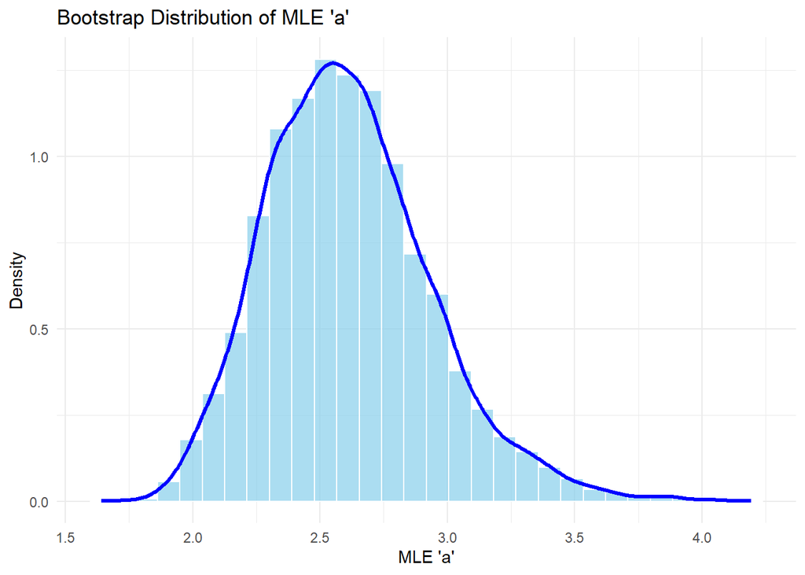

```r
# ----------------- GRAPHING BOOTSTRAP 'a' MLE -----------------------------------------------------------------------
df_mle_a <- data.frame(mle_a_hat = bootstrap_a_mle)
# df_mle_a: ggplot cannot take vectors, so we need to create a data frame to give it

p_a <- ggplot(df_mle_a, aes(x = mle_a_hat)) +
geom_histogram(aes(y = ..density..), bins = 30, fill = "skyblue", color = "white", alpha = 0.7) +
geom_density(kernel = "gaussian", color = "blue", linewidth = 1.2) +
labs(
title = "Bootstrap Distribution of MLE 'a'",
x = "MLE 'a'",
y = "Density"
) +
theme_minimal()
p_a
```

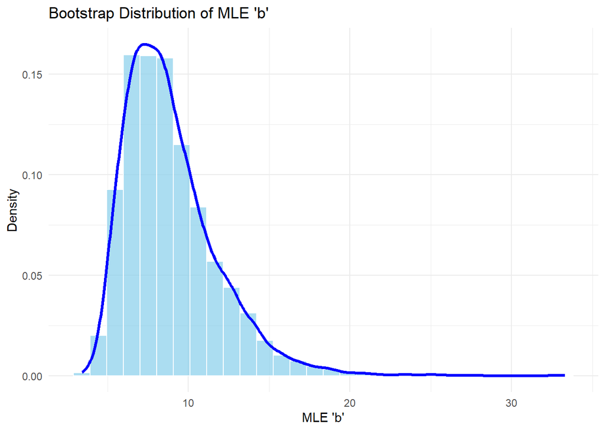

```r
# ----------------- GRAPHING BOOTSTRAP 'b' MLE -----------------------------------------------------------------------
df_mle_b <- data.frame(mle_b_hat = bootstrap_b_mle)
# df_mle_b: ggplot cannot take vectors, so we need to create a data frame to give it

p_b <- ggplot(df_mle_b, aes(x = mle_b_hat)) +
geom_histogram(aes(y = ..density..), bins = 30, fill = "skyblue", color = "white", alpha = 0.7) +
geom_density(kernel = "gaussian", color = "blue", linewidth = 1.2) +
labs(
title = "Bootstrap Distribution of MLE 'b'",
x = "MLE 'b'",
y = "Density"
) +
theme_minimal()
p_b
```

(2). Construct both the $95\%$ **bootstrap confidence interval** and the **Wald confidence interval** for $b$. Do these intervals agree with the results obtained in **Problem B2**? [*Compute the standard error of $\hat{b}$ using the observed Fisher information matrix, i.e., the inverse of the negative Hessian obtained from optim()*]

**Bootstrap Percentile CI for b:**

```r
boot_ci_b <- quantile(bootstrap_b_mle, probs = c(0.025, 0.975))
# we already computed the bootstrap mles of b. Just find the 2.5th and 97.5th percentiles
boot_ci_b
```

```
     2.5%     97.5%
 5.012846 15.816522
```

**Wald CI for b:**

```r
H <- mle_result$hessian
# this is the Hessian computed in problem B1
Fisher_obs <- -H
# negative hessian is the observed fisher information
var_cov <- solve(Fisher_obs)
# finding the inverse of the fisher information gives the variance covariance matrix
se_b <- sqrt(var_cov[2, 2])
# variance of b is located in row 2 column 2 of the var cov matrix. Sqrt(variance) = SE.

b_hat <- unname(mle_result$par["b_hat"])
# this is the mle of b computed in problem B1
z_crit <- qnorm(0.975)
# critical value computed for two tailed 95% confidence

wald_ci_b <- c(
  b_hat - z_crit * se_b,
  b_hat + z_crit * se_b
)
wald_ci_b
```

```
[1]  3.484026 12.282717
```

**Answer:**

Both the 95% bootstrap percentile confidence interval and the 95% Wald confidence interval for 𝑏 lie entirely above the null value 𝑏 = 1 . Therefore, neither interval provides support for the null hypothesis 𝐻 0 : 𝑏 = 1 . This conclusion is fully consistent with the likelihood ratio test result in Problem B2, where we rejected 𝐻 0 : 𝑏 = 1 at the 5% significance level.

(3). Based on the bootstrap sampling distributions from part (1) of this problem, assess whether the validity of the Wald confidence interval is supported.

**Answer:**

### **Problem B4**:

In the introduction to the working model for this exam, the Kumaraswamy distribution reduces to the uniform distribution on (0,1). In this problem, we perform a **likelihood ratio test** for the following hypothesis to assess whether the data come from the uniform distribution on (0,1):

$$H_0: a = 1\quad \& \quad b = 1\quad \text{ versus } \quad H_a: a \ne
1 \quad \text{or} \quad b \ne 1 \quad \text{or}\quad (a \ne 1 \quad
\& \quad b \ne 1).$$

Provide a practical interpretation of the above test result. [*Hint: $H_a$ basically says that there is no constraints for $a$ and $b$. Please review the lecture note for module 11 on the likelihood ratio test before coding.*]

Recall full log-likelihood function:
$$\ell(\theta \mid x)
= n \log a
+ n \log b
+ (a-1)\sum_{i=1}^n \log x_i
+ (b-1)\sum_{i=1}^n \log\left(1 - x_i^{a}\right)$$

Likelihood ratio test statistic:
$$\Lambda
= 2\big(\ell_{\text{full}}(a_{\text{MLE_unconstrained}},
b_{\text{MLE_unconstrained}}) - \ell_{\text{full}}(a = 1, b = 1)\big)
= 2\big(\ell_{\text{full}}(a_{\text{MLE_unconstrained}},
b_{\text{MLE_unconstrained}})\big)$$

```r
# Calculate the LRT statistic and display it
# These are the same variables and functions that we used to solve problem B2
ll_full <- kumar_loglik_full(unconstrained_params, water_storage)
LRT_uniform <- 2 * ll_full
LRT_uniform
```

```
[1] 49.12542
```

$$\Lambda \sim \chi^{2}_{2}
\quad\text{the full model has 2 parameters and the null has 0, giving 2
degrees of freedom}$$

Critical value:

```r
crit_val <- qchisq(0.95, df = 2)
crit_val
```

```
[1] 5.991465
```

P-value:

```r
# Compute the p-value for the likelihood ratio test
# pchisq(x, df, lower.tail = FALSE) returns P(X > x)
# This gives the right-tail probability under a chi-square(df = 2) distribution
pchisq(LRT_uniform, df = 2, lower.tail = FALSE)
```

```
[1] 2.150558e-11
```

**Conclusion:**
$$\text{Reject } H_0
\quad \text{since} \quad
\Lambda > \chi^2_{2,0.95}
\quad \text{or equivalently since} \quad
p\text{-value} < 0.05$$

**Practical Interpretation:**

From Problem B2, we already found strong evidence that the data do not come from a power distribution. The likelihood ratio test in that problem rejected the hypothesis 𝑏 = 1 , meaning the simpler one‑parameter power model could not adequately describe the data.

In the current problem, we tested an even more restrictive model: the Uniform(0,1) distribution, which corresponds to the Kumaraswamy distribution with 𝑎 = 1 and 𝑏 = 1 . The likelihood ratio test again produced a large test statistic with a very small p‑value, leading us to reject the null hypothesis that 𝑎 = 1 and 𝑏 = 1 .

Taken together, these results show that: The data do not follow a power distribution (B2). The data do not follow a uniform distribution on (0,1) (this problem). Therefore, the data require the full two‑parameter Kumaraswamy model to capture their behavior.

In practical terms, this means the probability of observing values in (0,1) is not constant (as the uniform would require) and not governed by a single shape parameter (as the power model would require). The data exhibit structure that necessitates both parameters 𝑎 and 𝑏 being freely estimated.

**Note**: Please download the template and insert your work into it to complete the exam.